# CSCI 4148 - Practical 1

Joel Richards

## Introduction

### Understanding the Data

1. Use the data dictionary describe each of the variables/features in the CSV in your report.
   1. PatientID: Unique identifier for each patient
   2. AppointmentID: Unique identifier to each appointment
   3. Gender: Patient Gender (limited to Male or Female)
   4. ScheduledDate: date on which the appointment was scheduled
   5. AppointmentDate: date of the actual appointment
   6. Age: Patient age
   7. Neighbourhood: District of Vitória in which the appointment
   8. SocialWelfare: Patient is a recipient of Bolsa Família welfare payments
   9. Hypertension: Patient previously diagnoised with hypertensio (Boolean)
   10. Diabetes: Patient previously diagnosed with diabetes (Boolean)
   11. AlcoholUseDisorder: Patient previously diagnosed with alcohol use disorder (Boolean)
   12. Disability: Patient previously diagnosed with a disability (severity rated 0-4)
   13. SMSReceived: At least 1 reminder text sent before appointment (Boolean)
   14. NoShow: Patient did not attend scheduled appointment (Boolean: Yes/No)
2. Can you think of 3 hypotheses for why someone may be more likely to miss a medical appointment?
   1. Younger people will be more likely to miss an appointment.
   2. Those who have not received an SMS reminder text will be more likely to miss an appointment.
   3. Appointments scheduled well in advance of the actual appointment date will be more likely to have a no-show.
3. Can you provide 3 examples of important contextual information that is missing in this data dictionary and dataset that could impact your analyses
   1. There is no indication of the type of appointment in the dataset.
   2. The dataset does not include any information about which neighborhood the patient lives in (so as to make a comparison between their home and appointment locations).
   3. There’s no data for the doctor for each appointment. This information could help determine if certain doctors have more missed appointments. This is assuming there are more than one doctor per clinic.

```r
library(readr)          # Data Input
library(tidymodels)     # Data Manipulation
library(lubridate)      # Data Manupulation
library(dplyr)          # Data Manipulation
library(reshape2)       # Data Manipulation
library(caTools)        # Data Manipulation
library(corrplot)       # Data Visualisation
library(ggplot2)        # Data Visualization
library(viridis)        # Data Visualization
library(ggthemes)       # Data Visualization
library(pROC)           # Metrics
library(caret)          # Machine Learning
```

## Data Parsing and Cleaning

4 Modify the following to make it reproducible i.e., downloads the data file directly from version control

```r
data_link <- "https://raw.githubusercontent.com/maguire-lab/health_data_science_research/master/static_files/practicals/lab1_data/2016_05v2_VitoriaAppointmentData.csv"
raw.data <- read_csv(data_link, col_types='ccfTTicllllflf')

raw.data %>% filter(Age == 0) %>% select(Hypertension, Diabetes, AlcoholUseDisorder) %>% unique()
```

| Hypertension | Diabetes | AlcoholUseDisorder |
| --- | --- | --- |
| FALSE | FALSE | FALSE |

```r
count(raw.data, Neighbourhood, sort = TRUE)
```

| Neighbourhood | n |
| --- | --- |
| JARDIM CAMBURI | 7717 |
| MARIA ORTIZ | 5805 |
| RESISTÊNCIA | 4431 |
| JARDIM DA PENHA | 3877 |
| ITARARÉ | 3514 |
| CENTRO | 3334 |
| TABUAZEIRO | 3132 |
| SANTA MARTHA | 3131 |
| JESUS DE NAZARETH | 2853 |
| BONFIM | 2773 |

[output cut: 71 more lines]

5 Are there any individuals with impossible ages? If so we can drop this row using filter i.e., `data <- data %>% filter(CRITERIA)`

```r
raw.data <- raw.data %>% filter(Age >= 0)
```

## Exploratory Data Analysis

```r
count(raw.data, PatientID, sort = TRUE)
```

| PatientID | n |
| --- | --- |
| 822145925426128 | 88 |
| 99637671331 | 84 |
| 26886125921145 | 70 |
| 33534783483176 | 65 |
| 258424392677 | 62 |
| 6264198675331 | 62 |
| 75797461494159 | 62 |
| 871374938638855 | 62 |
| 66844879846766 | 57 |
| 872278549442 | 55 |

[output cut: 990 more lines]

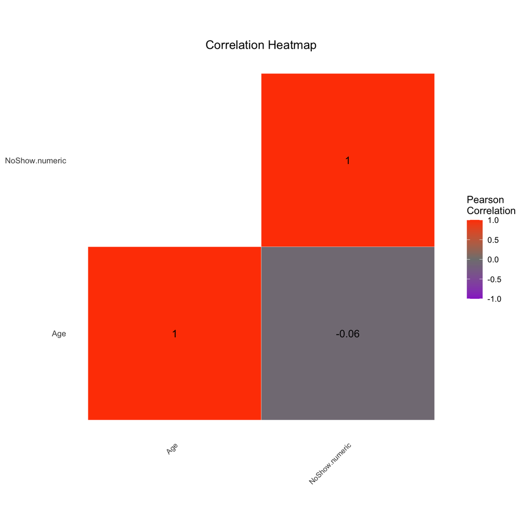

```r
# let's define a plotting function
corplot = function(df){
  cor_matrix_raw <- round(cor(df),2)
  cor_matrix <- melt(cor_matrix_raw)


  #Get triangle of the correlation matrix
  #Lower Triangle
  get_lower_tri<-function(cor_matrix_raw){
    cor_matrix_raw[upper.tri(cor_matrix_raw)] <- NA
    return(cor_matrix_raw)
  }

  # Upper Triangle
  get_upper_tri <- function(cor_matrix_raw){
    cor_matrix_raw[lower.tri(cor_matrix_raw)]<- NA
    return(cor_matrix_raw)
  }


  upper_tri <- get_upper_tri(cor_matrix_raw)

  # Melt the correlation matrix
  cor_matrix <- melt(upper_tri, na.rm = TRUE)

  # Heatmap Plot
  cor_graph <- ggplot(data = cor_matrix, aes(Var2, Var1, fill = value))+
    geom_tile(color = "white")+
    scale_fill_gradient2(low = "darkorchid", high = "orangered", mid = "grey50",
                         midpoint = 0, limit = c(-1,1), space = "Lab",
                         name="Pearson\nCorrelation") +
    theme_minimal()+
    theme(axis.text.x = element_text(angle = 45, vjust = 1,
                                     size = 8, hjust = 1))+
    coord_fixed()+ geom_text(aes(Var2, Var1, label = value), color = "black", size = 4) +
    theme(
      axis.title.x = element_blank(),
      axis.title.y = element_blank(),
      panel.grid.major = element_blank(),
      panel.border = element_blank(),
      panel.background = element_blank(),
      axis.ticks = element_blank())+
      ggtitle("Correlation Heatmap")+
      theme(plot.title = element_text(hjust = 0.5))

  cor_graph
}

raw.data$NoShow.numeric = as.numeric(ifelse(raw.data$NoShow=="Yes",1,0))

# Find all numerical vars in dataframe
numerical.vars = sapply(raw.data, is.numeric)

# Plot Correlation Heatmap
corplot(raw.data[,numerical.vars])
```

**7 Which parameters most strongly correlate with missing appointments (NoShow)?**

**8 Are there any other variables which strongly correlate with one another?**

**9 Do you see any issues with PatientID/AppointmentID being included in this plot?**

```r
ggplot(raw.data,aes(x=Age,fill=`NoShow`))+
  geom_density(color="white",alpha=0.8)+
  ggtitle("Density of Age across No Show")+
  scale_fill_manual(values=c("grey50","orangered"))
```

[output not shown]

```r
raw.data$Age.Range = cut(raw.data$Age,breaks = seq(0,120,10))
ggplot(raw.data,aes(x=Age.Range,y=1,fill=NoShow))+
  geom_bar(stat="identity",width=0.5)+
  ggtitle("Amount of No Show across Age Ranges")+
  scale_fill_manual(values=c("grey50","orangered"))
```

[output not shown]

```r
ggplot(raw.data,aes(x=Age.Range,y=1,fill=NoShow))+
  geom_bar(stat="identity",position="fill",width=0.5)+
  ggtitle("Proportion of No Show across Age Ranges")+
  scale_fill_manual(values=c("grey50","orangered"))
```

[output not shown]

**10 How could you be misled if you only plotted 1 of these 2 plots of attendance by age group?**

```r
sum(raw.data$Age == 0)
```

```r
ggplot(raw.data) +
  geom_bar(aes(x=SMSReceived, fill=NoShow), alpha=0.8) +
  ggtitle("Density of SMS received across Age and No Show")
```

[output not shown]

```r
ggplot(raw.data) +
  geom_bar(aes(x=SMSReceived, fill=NoShow), position='fill', alpha=0.8) +
  ggtitle("Density of SMS received across Age and No Show")
```

[output not shown]

**11 From this plot does it look like SMS reminders increase or decrease the chance of someone not attending an appointment? Why might the opposite actually be true (hint: think about biases)?**

**12 Create a similar plot which compares the the density of NoShow across the values of disability**

```r
ggplot(raw.data) +
  geom_bar(aes(x=Disability, fill=NoShow), position='fill', alpha=0.8) +
  ggtitle("Density of SMS received across Age and No Show")
```

[output not shown]

```r
ggplot(raw.data) +
  geom_bar(aes(x=Neighbourhood, fill=NoShow)) +
  theme(axis.text.x = element_text(angle=45, hjust=1, size=5)) +
  ggtitle('Attendance by Neighbourhood')
```

[output not shown]

```r
ggplot(raw.data) +
  geom_bar(aes(x=Neighbourhood, fill=NoShow), position='fill') +
  theme(axis.text.x = element_text(angle=45, hjust=1, size=5)) +
  ggtitle('Proportional Attendance by Neighbourhood')
```

[output not shown]

**13 Suggest a reason for differences in attendance rates across neighbourhoods.**

```r
ggplot(raw.data) +
  geom_bar(aes(x=Gender, fill=NoShow)) +
  ggtitle("Gender by attendance")
```

[output not shown]

```r
ggplot(raw.data) +
  geom_bar(aes(x=Gender, fill=NoShow), position='fill') +
  ggtitle("Gender by Attendance")
```

[output not shown]

**14 Create a similar plot using SocialWelfare**

```r
ggplot(raw.data) +
  geom_bar(aes(x=SocialWelfare, fill=NoShow), position='fill') +
  ggtitle("Welfare Usage by Attendance")
```

[output not shown]

## Feature Engineering

```r
raw.data <- raw.data %>% mutate(AppointmentDay = wday(AppointmentDate, label=TRUE, abbr=TRUE),
                                 ScheduledDay = wday(ScheduledDate,  label=TRUE, abbr=TRUE))

ggplot(raw.data) +
  geom_bar(aes(x=AppointmentDay, fill=NoShow)) +
  ggtitle("Amount of No Show across Appointment Day")
```

[output not shown]

```r
ggplot(raw.data) +
  geom_bar(aes(x=AppointmentDay, fill=NoShow), position = 'fill') +
  ggtitle("Amount of No Show across Appointment Day")
```

[output not shown]

```r
raw.data <- raw.data %>% mutate(Lag.days=difftime(AppointmentDate, ScheduledDate, units = "days"),
                                Lag.hours=difftime(AppointmentDate, ScheduledDate, units = "hours"))

ggplot(raw.data) +
  geom_density(aes(x=Lag.days, fill=NoShow), alpha=0.7)+
  ggtitle("Density of Lag (days) by attendance")
```

[output not shown]

**15 Have a look at the values in lag variable, does anything seem odd?**

## Predictive Modeling

```r
data.prep = raw.data %>% select(Gender, Lag, Age, ScheduledDay,
                                AppointmentDay, Neighbourhood, SocialWelfare,
                                Hypertension, Diabetes, NoShow,
                                AlcoholUseDisorder, Disability, SMSReceived) %>%
                          mutate(Gender = as.factor(Gender),
                                 NoShow = as.factor(NoShow),
                                 Neighbourhood = as.factor(Neighbourhood))
set.seed(41)
splitr = sample.split(data.prep$NoShow, SplitRatio = 0.7)
train  = subset(data.prep,splitr == TRUE)
test   = subset(data.prep,splitr == FALSE)
```

```r
fit.control <- trainControl(method="cv",number=3,
                           classProbs = TRUE, summaryFunction = twoClassSummary)
```

**16 Based on the EDA, how well do you think this is going to work?**

```r
xgb.grid <- expand.grid(eta=c(0.05),
                       max_depth=c(4),colsample_bytree=1,
                       subsample=1, nrounds=500, gamma=0, min_child_weight=5)

xgb.model <- train(NoShow ~ .,data=train, method="xgbTree",metric="ROC",
                  tuneGrid=xgb.grid, trControl=fit.control)

xgb.pred <- predict(xgb.model, newdata=test)
xgb.probs <- predict(xgb.model, newdata=test, type="prob")
```

```r
test <- test %>% mutate(NoShow.numerical = ifelse(NoShow=="Yes",1,0))
confusionMatrix(xgb.pred, test$NoShow, positive="Yes")
```

```r
paste("XGBoost Area under ROC Curve: ", round(auc(test$NoShow.numerical, xgb.probs[,2]),3), sep="")
```

```r
xgb.probs$Actual = test$NoShow.numerical
xgb.probs$ActualClass = test$NoShow
xgb.probs$PredictedClass = xgb.pred
xgb.probs$Match = ifelse(xgb.probs$ActualClass == xgb.probs$PredictedClass,
                         "Correct","Incorrect")
# [4.8] Plot Accuracy
xgb.probs$Match = factor(xgb.probs$Match,levels=c("Incorrect","Correct"))
ggplot(xgb.probs,aes(x=Yes,y=Actual,color=Match))+
  geom_jitter(alpha=0.2,size=0.25)+
  scale_color_manual(values=c("grey40","orangered"))+
  ggtitle("Visualizing Model Performance", "(Dust Plot)")
```

[output not shown]

```r
results = data.frame(Feature = rownames(varImp(xgb.model)$importance)[1:10],
                     Importance = varImp(xgb.model)$importance[1:10,])

results$Feature = factor(results$Feature,levels=results$Feature)


# [4.10] Plot Variable Importance
ggplot(results, aes(x=Feature, y=Importance,fill=Importance))+
  geom_bar(stat="identity")+
  scale_fill_gradient(low="grey20",high="orangered")+
  ggtitle("XGBoost Variable Importance")+
  theme(axis.text.x = element_text(angle = 45, hjust = 1))
```

[output not shown]

**17 Using the caret package fit and evaluate 1 other ML model on this data.**

**18 Based on everything, do you think we can trust analyses based on this dataset? Explain your reasoning.**